# R Notebook

Here’s a brief summary of the methodology used in the code:

Load the required packages: The packages dplyr, tidyr, readr, ggplot2, ggbiplot, usmap, and data.table are loaded.

Load and clean the data: The “countypres.csv” file is read in using the read_csv function from readr. Rows with party other than “REPUBLICAN” and totalvotes less than or equal to 0 are removed. The data is then pivoted wider so that the different election years are represented as columns. The county_fips column is renamed as fips.

Visualize the data: The summarized data is gathered so that the election year columns become rows. A ggplot is created with x-axis representing the election year, y-axis representing the vote ratio for each county, and each line representing a county.

Visualize the PCA results: Summary statistics and structure of the PCA object are viewed using the summary and str functions, respectively. The ggbiplot function is used to create a biplot of the first two principal components.

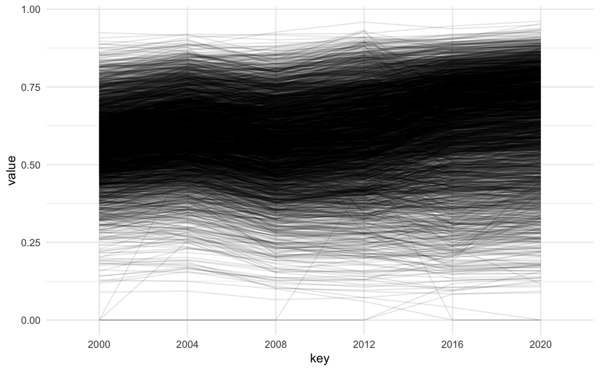

```r
# Load required packages
# Load required packages
library(dplyr)
library(tidyr)
library(readr)
library(ggplot2)
library(RColorBrewer)
library(data.table)
library(ggbiplot)
library(usmap)

# Load data
pre <- read_csv(file = "countypres.csv") %>%
  filter(party == "REPUBLICAN") %>%
  filter(totalvotes > 0) %>%
  mutate(ratio = candidatevotes/ totalvotes) %>%
  pivot_wider(names_from = year, values_from = ratio) %>%
  rename_with(~ "fips", .cols = "county_fips")
# Summarize data
pre <- pre %>%
  dplyr::select(fips, "2000":"2020") %>%
  group_by(fips) %>%
  dplyr::summarise_all(sum, na.rm = T)

pre %>%
  gather("key","value", "2000":"2020") %>%
  ggplot(aes(x = key, y = value, group = fips)) +
  geom_line(alpha = 0.1) +
  theme_minimal()
```

```r
# Perform PCA
pre.pca <- prcomp(transpose(pre[,-1]), scale. = TRUE)

summary(pre.pca)
```

```
Importance of components:
                           PC1     PC2      PC3      PC4     PC5       PC6
Standard deviation     43.9113 26.9194 16.20763 12.47441 9.26507 9.659e-14
Proportion of Variance  0.6108  0.2295  0.08321  0.04929 0.02719 0.000e+00
Cumulative Proportion   0.6108  0.8403  0.92352  0.97281 1.00000 1.000e+00
```

```r
str(pre.pca)
```

```
List of 5
 $ sdev    : num [1:6] 43.91 26.92 16.21 12.47 9.27 ...
 $ rotation: num [1:3157, 1:6] -0.000291 0.013307 0.010595 0.019215 0.01905 ...
  ..- attr(*, "dimnames")=List of 2
  .. ..$ : chr [1:3157] "V1" "V2" "V3" "V4" ...
  .. ..$ : chr [1:6] "PC1" "PC2" "PC3" "PC4" ...
 $ center  : Named num [1:3157] 0.726 0.757 0.513 0.72 0.835 ...
  ..- attr(*, "names")= chr [1:3157] "V1" "V2" "V3" "V4" ...
 $ scale   : Named num [1:3157] 0.0201 0.0176 0.0255 0.0635 0.0716 ...
  ..- attr(*, "names")= chr [1:3157] "V1" "V2" "V3" "V4" ...
 $ x       : num [1:6, 1:6] -51 -19.49 -29.53 -5.93 44.64 ...
  ..- attr(*, "dimnames")=List of 2
  .. ..$ : NULL
  .. ..$ : chr [1:6] "PC1" "PC2" "PC3" "PC4" ...
 - attr(*, "class")= chr "prcomp"
```

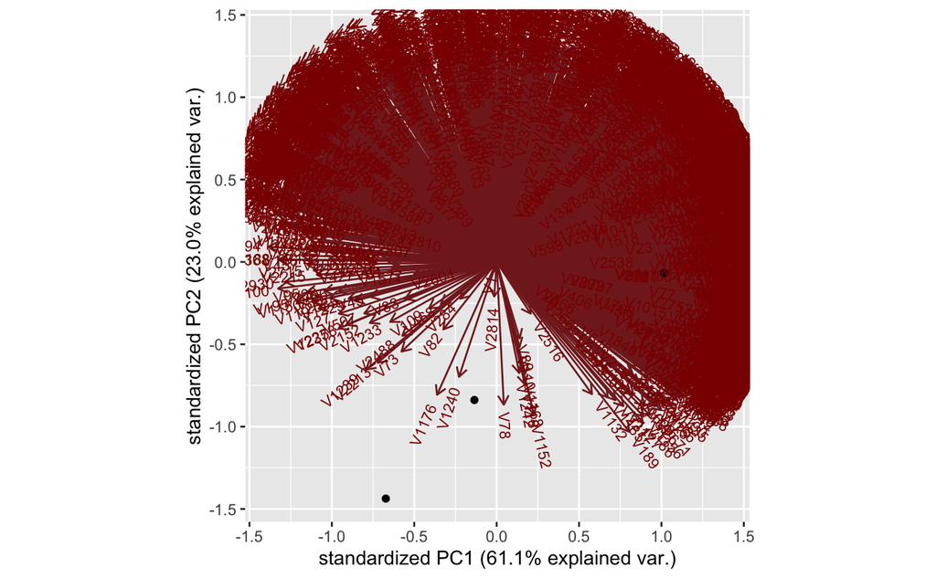

```r
ggbiplot(pre.pca)
```

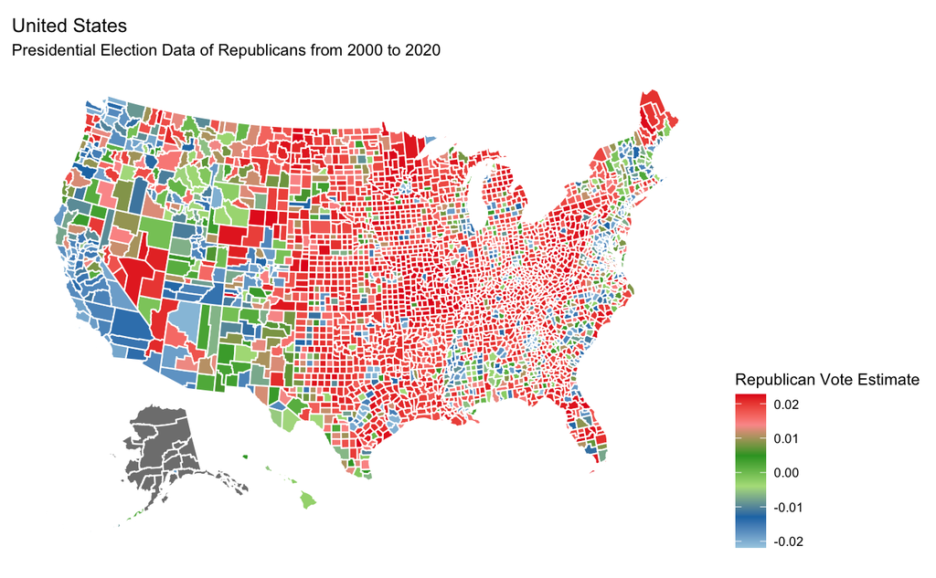

```r
# Generate color palette
colors <- brewer.pal(n = 6, name = "Paired")

# Plot county vote estimates
# plot_usmap(data = cbind(pre, pre.pca$rotation[,1]), values = "pre.pca$rotation[, 1]", color = "white") +
#  scale_fill_gradientn(colors = colors, name = "Republican Vote Estimate", label = scales::comma) +
#   labs(title = "United States", subtitle = "Presidential Election Data of Republicans from 2000 to 2020") +
#   theme(legend.position = "right")

plot_usmap(data = cbind(pre, pre.pca$rotation[,1]),
           values = "pre.pca$rotation[, 1]",
           color = "white") +
  scale_fill_gradientn(colors = colors, name = "Republican Vote Estimate",
                       label = scales::comma) +
  labs(title = "United States",
       subtitle = "Presidential Election Data of Republicans from 2000 to 2020") +
  theme(legend.position = "right")
```